# NYCFlights: Arrival Delay Regression Model (Open Ended Variation)

Raul Torres

April 16, 2017

# NYCFlights Model

Using the rectangular data that you created last week create a model for `arr_delay`. Follow a well defined process for creating a model as discussed in class or from one of the readings.

Break the process down into steps and create a codeblock for each step. - Use as many steps you feel as necessary - Concisely explain each step - Show all work

(You can start with the data that you created last week.)

## Step 1: Load data and plot dependent variable

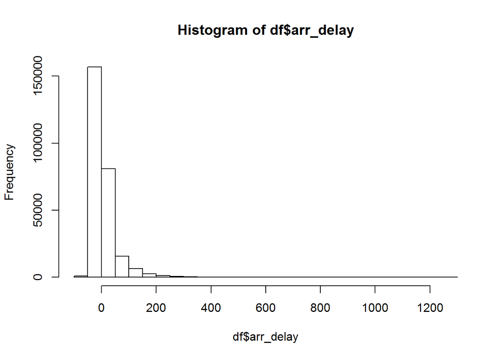

```r
p <- "C:/Users/rtorres/Desktop/MachLearn/MyUser/CSX460/03-linear-regression/03-exercise-nycflights-model"
df <- read.csv(paste0(p,"/NYCflights.csv"), stringsAsFactors = FALSE)
hist(df$arr_delay)
```

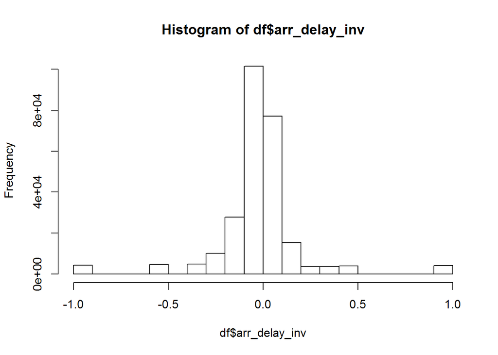

```r
# in order to have a more Normal distribution of "y", we transform to inverse of y
df$arr_delay_inv <- (df$arr_delay^(-1))
hist(df$arr_delay_inv)
```

```r
# because changing to inverse would make the impacts on y more difficult to interpret, we stick to y.
```

## Step 2: Fit the dummy model and select another model. Display results

```r
model.dummy <- lm(arr_delay ~ 1, df) #<- same as y-bar
(mean(df$arr_delay, na.rm = TRUE))
```

```
## [1] 6.742718
```

```r
summary(model.dummy)
```

```
##
## Call:
## lm(formula = arr_delay ~ 1, data = df)
##
## Residuals:
##     Min      1Q  Median      3Q     Max
##  -81.74  -23.74  -11.74    7.26 1265.26
##
## Coefficients:
##             Estimate Std. Error t value Pr(>|t|)
## (Intercept)  6.74272    0.08587   78.52   <2e-16 ***
## ---
## Signif. codes:  0 '***' 0.001 '**' 0.01 '*' 0.05 '.' 0.1 ' ' 1
##
## Residual standard error: 44.24 on 265416 degrees of freedom
##   (7371 observations deleted due to missingness)
```

```r
model1 <- lm(arr_delay ~ carrier + month.flight + distance + precip + wind_gust + wind_speed + speed + model + dest + origin, data = df)
summary(model1)
```

```
##
## Call:
## lm(formula = arr_delay ~ carrier + month.flight + distance +
##     precip + wind_gust + wind_speed + speed + model + dest +
##     origin, data = df)
##
## Residuals:
##      Min       1Q   Median       3Q      Max
## -113.048  -21.201   -7.868   11.213  250.698
##
## Coefficients: (3 not defined because of singularities)
##                    Estimate Std. Error t value Pr(>|t|)
## (Intercept)      -3.120e+02  1.384e+03  -0.225   0.8217
## carrierDL         1.534e+01  8.028e+01   0.191   0.8485
## carrierMQ        -2.120e+01  1.400e+01  -1.514   0.1306
## month.flight     -9.772e-01  5.602e-01  -1.744   0.0815 .
## distance          5.429e-01  1.860e+00   0.292   0.7704
## precip            4.393e+02  2.291e+02   1.918   0.0556 .
## wind_gust        -9.583e+04  3.864e+04  -2.480   0.0134 *
## wind_speed        1.103e+05  4.447e+04   2.480   0.0134 *
## speed            -2.158e-01  2.306e-01  -0.936   0.3497
## model172E         2.274e+01  2.506e+01   0.908   0.3644
## model172M         9.835e+00  1.814e+01   0.542   0.5880
## model172N         8.638e+00  8.764e+00   0.986   0.3246
## model206B        -1.621e+01  8.466e+00  -1.915   0.0559 .
## model310Q         9.196e+00  2.169e+01   0.424   0.6717
## model421C        -6.286e+00  9.866e+00  -0.637   0.5243
## model65-A90       2.228e+00  3.046e+01   0.073   0.9417
## modelA185F               NA         NA      NA       NA
## modelDC-7BF       3.673e+01  3.330e+01   1.103   0.2704
## modelDC-9-51             NA         NA      NA       NA
## modelOTTER DHC-3  1.276e+01  8.039e+00   1.587   0.1129
## modelPA-28-180   -4.085e+00  8.890e+00  -0.459   0.6460
## modelPA-31-350    2.301e+01  1.530e+01   1.504   0.1331
## modelPA-32R-300          NA         NA      NA       NA
## destBNA           1.626e+01  1.037e+01   1.568   0.1174
## destCLE           1.581e+02  6.360e+02   0.249   0.8037
## destCLT           1.041e+02  4.050e+02   0.257   0.7972
## destCMH           1.396e+02  5.232e+02   0.267   0.7896
## destCRW           1.712e+02  5.894e+02   0.291   0.7715
```

[output cut: 9 more lines]

```
## destRDU           1.659e+02  6.140e+02   0.270   0.7871
## destSAN          -9.801e+02  3.142e+03  -0.312   0.7551
## destSFO          -1.012e+03  3.402e+03  -0.297   0.7662
## destSJU          -4.827e+02  1.562e+03  -0.309   0.7574
## destSTL          -1.148e+02  2.385e+02  -0.481   0.6305
## destXNA          -2.314e+02  7.182e+02  -0.322   0.7474
## originJFK        -4.018e+01  2.750e+01  -1.461   0.1444
## originLGA        -3.752e+01  3.039e+01  -1.235   0.2173
## ---
## Signif. codes:  0 '***' 0.001 '**' 0.01 '*' 0.05 '.' 0.1 ' ' 1
##
## Residual standard error: 39.28 on 696 degrees of freedom
##   (272050 observations deleted due to missingness)
## Multiple R-squared:  0.1916, Adjusted R-squared:  0.144
## F-statistic: 4.024 on 41 and 696 DF,  p-value: 1.109e-14
```

## Step 3: Evaluate model (e.g adjusted R^2, residual plot, magnitud and significance of features)

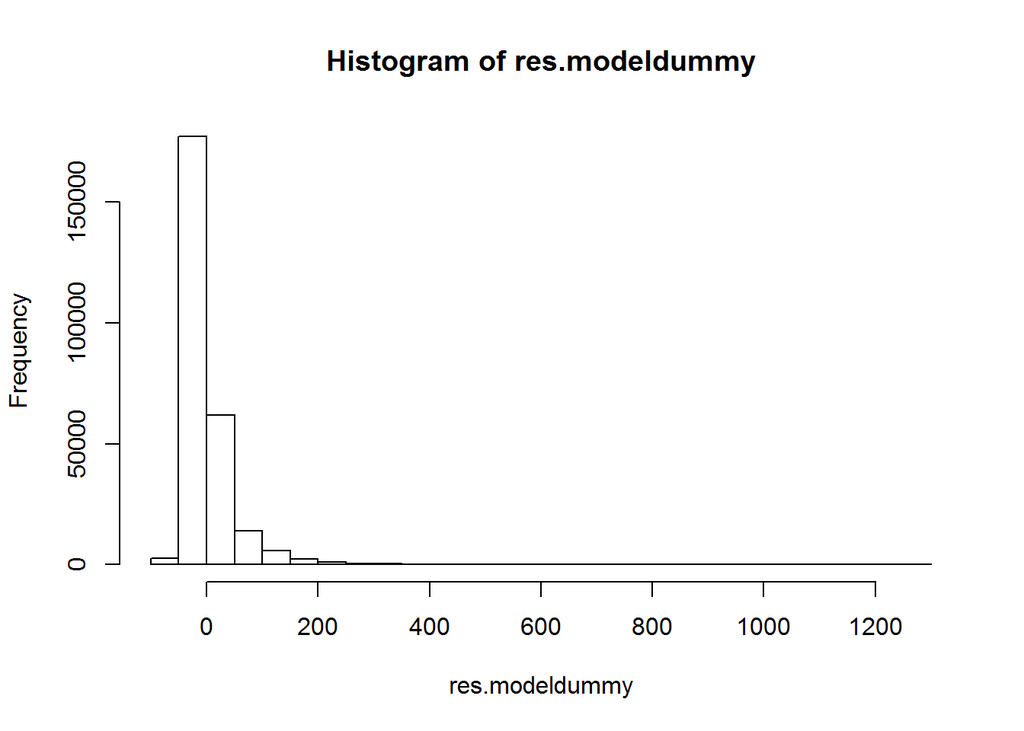

```r
res.modeldummy <- resid(model.dummy)
res.model1 <- resid(model1)

hist(res.modeldummy)
```

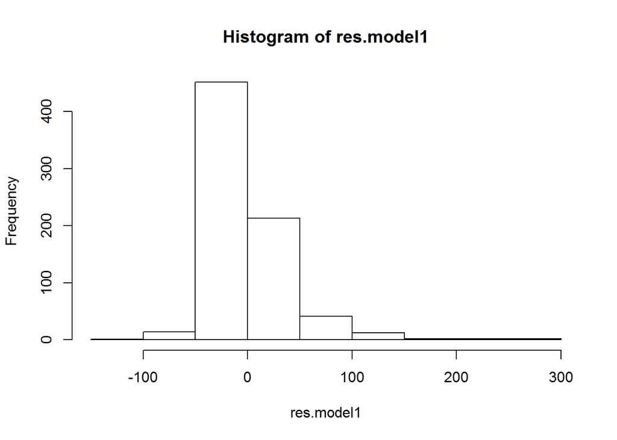

```r
hist(res.model1)
```

## Step 4: Fit a new (hopefully better) model

```r
df$date <- as.character(df$date)
df$xmas <- df$date %in% c("2013-12-21","2013-12-22","2013-12-23","2013-12-24","2013-12-26")

model2 <- lm(arr_delay ~ carrier + distance + month.flight + precip + wind_gust + wind_speed + speed + dest + origin + xmas, data = df)
summary(model2)
```

```
##
## Call:
## lm(formula = arr_delay ~ carrier + distance + month.flight +
##     precip + wind_gust + wind_speed + speed + dest + origin +
##     xmas, data = df)
##
## Residuals:
##     Min      1Q  Median      3Q     Max
## -79.716 -21.810  -7.773   9.674 253.302
##
## Coefficients:
##                Estimate Std. Error t value Pr(>|t|)
## (Intercept)   3.949e+02  1.327e+03   0.298  0.76612
## carrierDL    -2.334e+01  3.370e+01  -0.693  0.48881
## carrierMQ    -2.170e+01  1.254e+01  -1.731  0.08390 .
## distance     -4.281e-01  1.783e+00  -0.240  0.81033
## month.flight -8.807e-01  5.056e-01  -1.742  0.08194 .
## precip        4.093e+02  2.252e+02   1.818  0.06950 .
## wind_gust    -7.383e+04  3.813e+04  -1.936  0.05323 .
## wind_speed    8.496e+04  4.388e+04   1.936  0.05323 .
## speed        -9.376e-02  7.159e-02  -1.310  0.19072
## destBNA       2.011e+01  1.032e+01   1.949  0.05173 .
## destCLE      -1.652e+02  6.104e+02  -0.271  0.78680
## destCLT      -1.086e+02  3.882e+02  -0.280  0.77974
## destCMH      -1.269e+02  5.020e+02  -0.253  0.80052
## destCRW      -1.305e+02  5.657e+02  -0.231  0.81767
## destDCA      -7.149e+01  9.711e+02  -0.074  0.94134
## destDFW       2.171e+02  1.120e+03   0.194  0.84637
## destDTW      -1.202e+02  4.617e+02  -0.260  0.79474
## destEGE       3.952e+02  1.768e+03   0.224  0.82314
## destLAS       6.717e+02  2.660e+03   0.253  0.80072
## destMCO       7.759e+01  3.360e+02   0.231  0.81744
## destMIA       1.191e+02  5.957e+02   0.200  0.84158
## destMSP       1.154e+02  4.612e+02   0.250  0.80241
## destORD      -3.762e+01  4.964e+01  -0.758  0.44878
## destRDU      -1.483e+02  5.891e+02  -0.252  0.80137
## destSAN       6.787e+02  3.013e+03   0.225  0.82187
## destSFO       7.790e+02  3.263e+03   0.239  0.81138
## destSJU       3.404e+02  1.502e+03   0.227  0.82073
## destSTL       1.255e+01  2.290e+02   0.055  0.95629
## destXNA       1.539e+02  6.879e+02   0.224  0.82307
## originJFK    -2.980e+01  2.605e+01  -1.144  0.25289
## originLGA    -2.079e+01  2.923e+01  -0.711  0.47719
## xmasTRUE     -4.188e+01  1.572e+01  -2.665  0.00788 **
## ---
## Signif. codes:  0 '***' 0.001 '**' 0.01 '*' 0.05 '.' 0.1 ' ' 1
##
## Residual standard error: 39.46 on 706 degrees of freedom
##   (272050 observations deleted due to missingness)
## Multiple R-squared:  0.1729, Adjusted R-squared:  0.1366
## F-statistic:  4.76 on 31 and 706 DF,  p-value: 3.124e-15
```

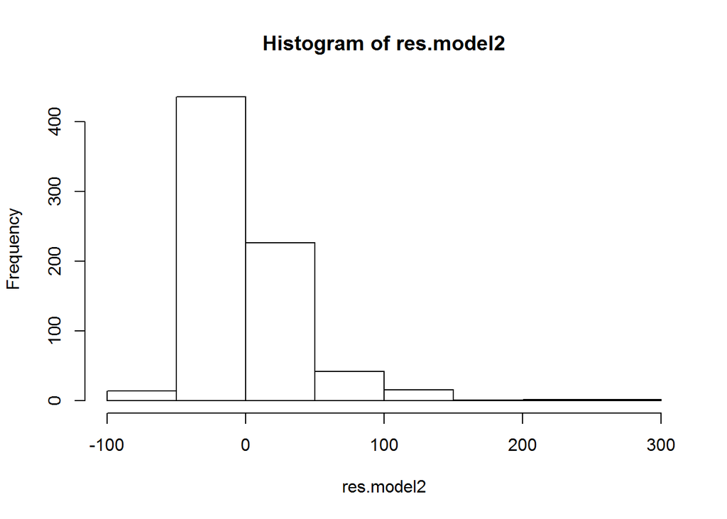

```r
res.model2 <- resid(model2)
hist(res.model2)
```

# Question:

Is this a good model?  
Judging by the R-squared, this model is not very good. In fact it is comparable to model 1 in terms of fit. The residual distribution looks very similar to model1 and both model1 and model2 seem to have little improvement from the dummy model (yhat)

Had time allowed, I would have liked to control for day of the week and more holiday seasons besides Christmas.